# Using Fonts in R (from Grok3)

This guide explains how to work with fonts in R, focusing on base R graphics, `ggplot2`, and external font integration. Fonts can enhance visualizations by improving readability and aesthetics.

## 1. Fonts in Base R Graphics

Base R plotting functions (e.g., ‘plot()’, ‘text()’) allow font customization via the ‘family’ argument or graphical parameters (‘par()’).

### Basic Usage

- The ‘family’ argument specifies the font family.
- Common options: “serif”, “sans”, “mono”.
- Example:

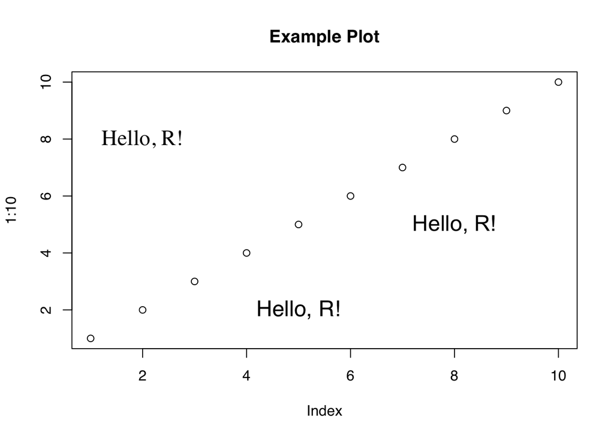

```r
plot(1:10, main = "Example Plot", family = "sans")
text(2, 8, "Hello, R!", family = "serif", cex = 1.5)
text(5, 2, "Hello, R!", family = "Helvetica", cex = 1.5)
text(8, 5, "Hello, R!", family = "ArialMT", cex = 1.5)
```

### Setting Fonts Globally

Use `par()` to set the default font for a plotting session:

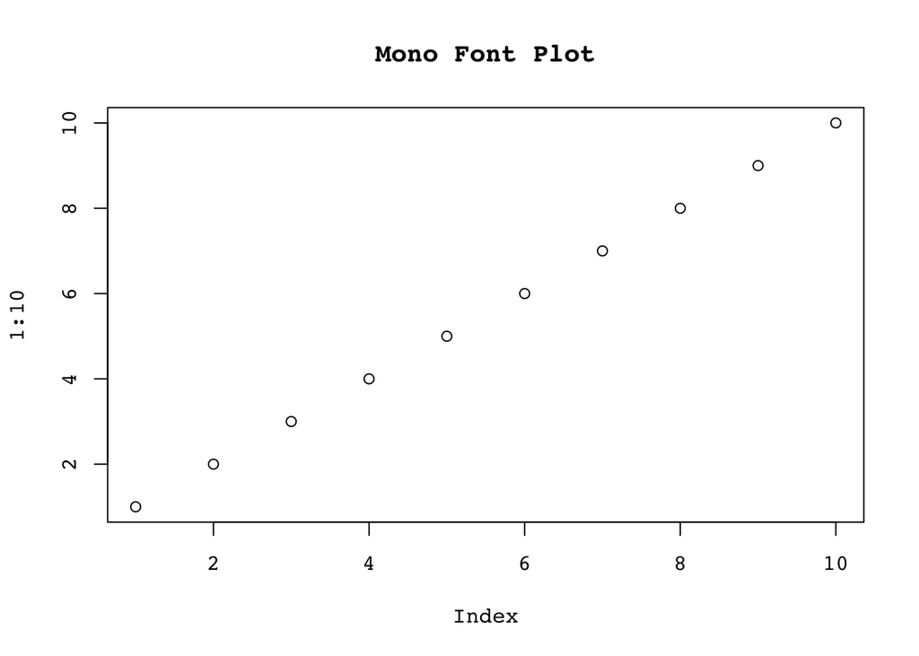

```r
par(family = "mono")
plot(1:10, main = "Mono Font Plot")
```

### Available Fonts

To see available font families in base R:

```r
names(postscriptFonts())
```

```
##  [1] "serif"                "sans"                 "mono"
##  [4] "AvantGarde"           "Bookman"              "Courier"
##  [7] "Helvetica"            "Helvetica-Narrow"     "NewCenturySchoolbook"
## [10] "Palatino"             "Times"                "URWGothic"
## [13] "URWBookman"           "NimbusMon"            "NimbusSan"
## [16] "URWHelvetica"         "NimbusSanCond"        "CenturySch"
## [19] "URWPalladio"          "NimbusRom"            "URWTimes"
## [22] "URW2Helvetica"        "URW2HelveticaItalic"  "URW2Times"
## [25] "NimbusMonoPS"         "ArialMT"              "ComputerModern"
## [28] "ComputerModernItalic" "Japan1"               "Japan1HeiMin"
## [31] "Japan1GothicBBB"      "Japan1Ryumin"         "Korea1"
## [34] "Korea1deb"            "CNS1"                 "GB1"
```

This lists PostScript font mappings, though availability depends on your system.

## 2. Fonts in ggplot2

### The `ggplot2` package offers more flexibility for font customization through themes and the `extrafont` or `showtext` packages.

### Basic Font Changes

#### Use `theme()` to adjust fonts for titles, labels, etc.:

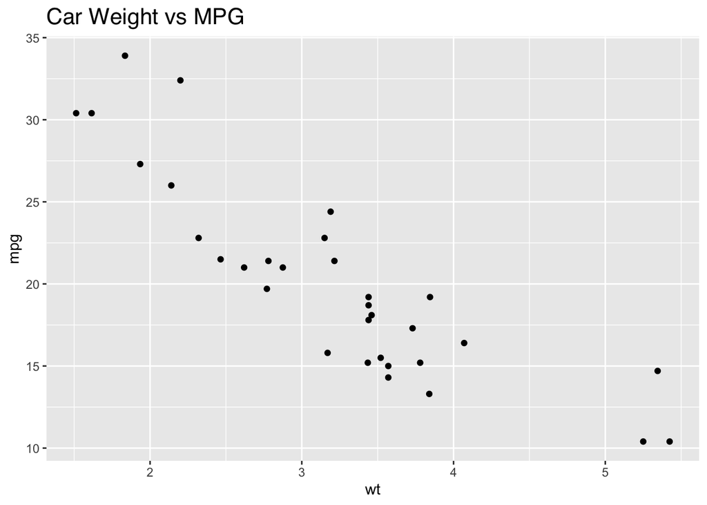

```r
library(ggplot2)

ggplot(mtcars, aes(x = wt, y = mpg)) +
  geom_point() +
  labs(title = "Car Weight vs MPG") +
  theme(plot.title = element_text(family = "sans", size = 16))
```

### Using System Fonts with `extrafont`

1. Install and load `extrafont`:

```r
   #install.packages("extrafont")
   library(extrafont)
```

2. Import system fonts (run once):

```r
   font_import()
```

```
## Importing fonts may take a few minutes, depending on the number of fonts and the speed of the system.
## Continue? [y/n]
```

```
## Exiting.
```

3. List available fonts:

```r
   fonts()
```

```
##   [1] ".SF Camera"                ".SF Compact Rounded"
##   [3] ".Keyboard"                 ".New York"
##   [5] ".SF Arabic"                ".SF Arabic Rounded"
##   [7] ".SF Armenian"              ".SF Armenian Rounded"
##   [9] ".SF Compact"               ".SF Georgian"
##  [11] ".SF Georgian Rounded"      ".SF Hebrew"
##  [13] ".SF Hebrew Rounded"        "System Font"
##  [15] ".SF NS Mono"               ".SF NS Rounded"
##  [17] "Academy Engraved LET"      "Andale Mono"
##  [19] "Apple Braille"             "AppleMyungjo"
##  [21] "Arial Black"               "Arial"
##  [23] "Arial Narrow"              "Arial Rounded MT Bold"
##  [25] "Arial Unicode MS"          "Bodoni Ornaments"
##  [27] "Bodoni 72 Smallcaps"       ""
##  [29] "Brush Script MT"           "Comic Sans MS"
```

[output cut: 58 more lines]

4. Use a specific font in `ggplot2`:

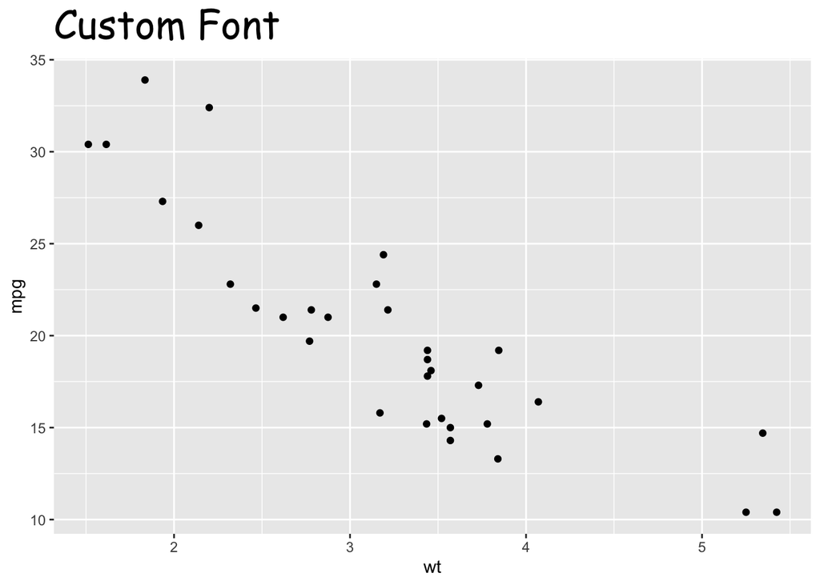

```r
   ggplot(mtcars, aes(x = wt, y = mpg)) +
     geom_point() +
     labs(title = "Custom Font") +
     theme(plot.title = element_text(family = "Comic Sans MS",size=24))
```

### Using `showtext` for More Flexibility

The `showtext` package simplifies font usage, especially for online fonts (e.g., Google Fonts): 1. Install and load:

```r
   #install.packages("showtext")
   library(showtext)
```

2. Enable `showtext`:

```r
   showtext_auto()
```

3. Load a Google Font:

```r
   sysfonts::font_add_google("Roboto", "roboto")
```

4. Use it in a plot:

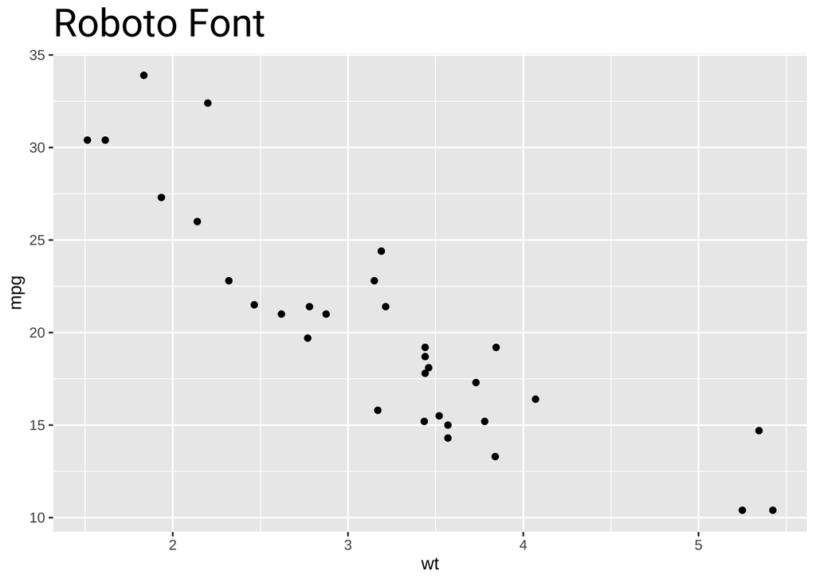

```r
   ggplot(mtcars, aes(x = wt, y = mpg)) +
     geom_point() +
     labs(title = "Roboto Font") +
     theme(plot.title = element_text(family = "roboto",size=24))
```

## 3. Platform-Specific Notes

- **Windows**: Fonts installed on your system are typically available.
- **MacOS**: Use `quartzFonts()` to map fonts in base R or rely on `extrafont`/`showtext`.
- **Linux**: Ensure fonts are installed via your package manager (e.g., `ttf` packages), then import them.

## 4. Tips

- Check font availability before plotting to avoid errors.
- Use `extrafont::fonttable()` or `sysfonts::font_files()` to debug font issues.
- For publication-quality plots, embed fonts when saving (e.g., with `extrafont::embed_fonts()` for PDFs).

## Example: Combining Everything

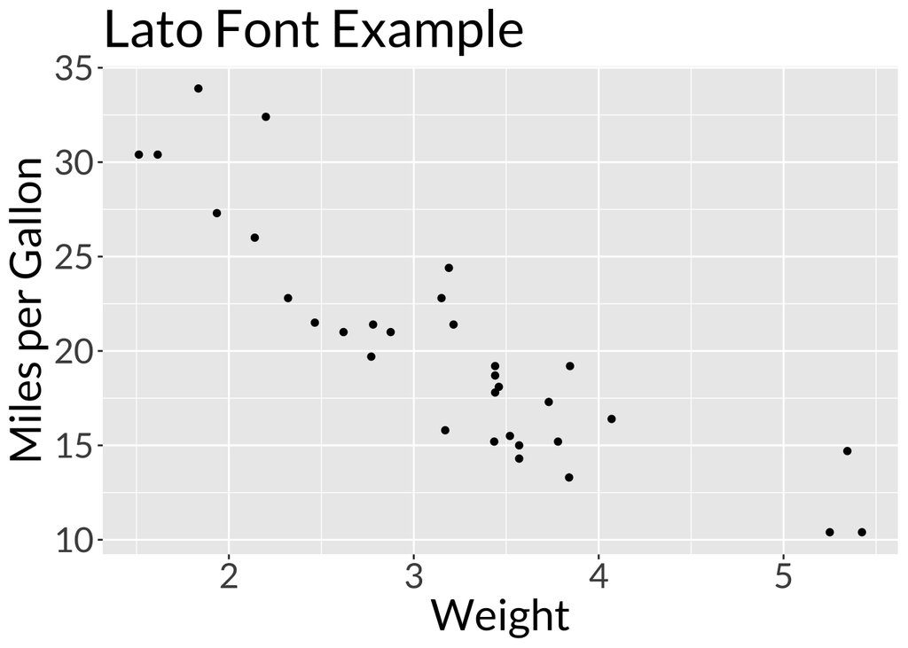

```r
library(ggplot2)
library(showtext)
showtext_auto()
sysfonts::font_add_google("Lato", "lato")

ggplot(mtcars, aes(x = wt, y = mpg)) +
  geom_point() +
  labs(title = "Lato Font Example", x = "Weight", y = "Miles per Gallon") +
  theme(text = element_text(family = "lato",size=24))
```

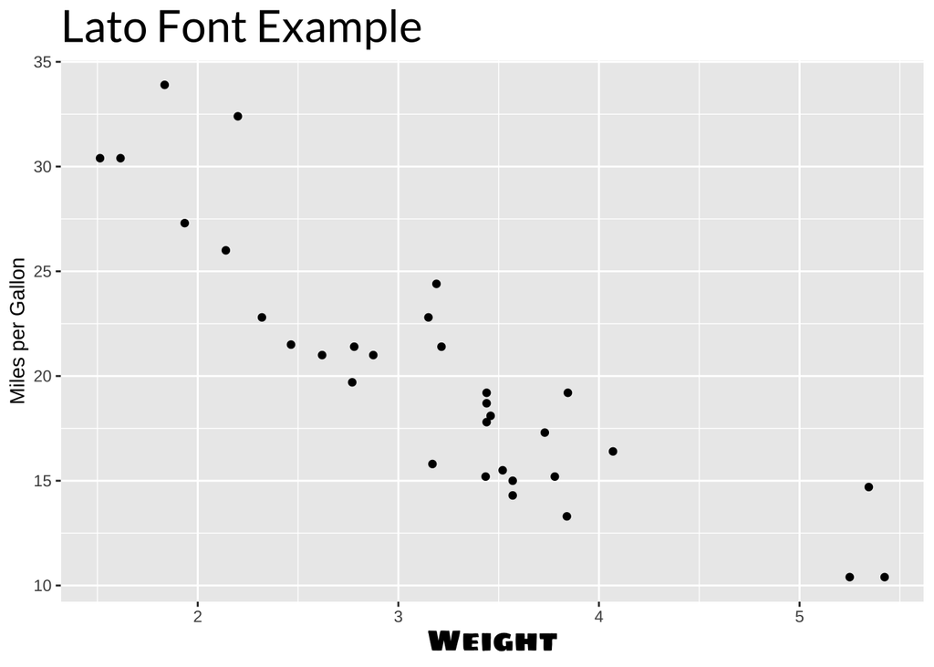

```r
library(ggplot2)
library(showtext)
showtext_auto()
sysfonts::font_add_google("Lato", "lato")
sysfonts::font_add_google("Sigmar One","sigmar")

ggplot(mtcars, aes(x = wt, y = mpg)) +
  geom_point() +
  labs(title = "Lato Font Example", x = "Weight", y = "Miles per Gallon") +
  theme(plot.title = element_text(family = "lato",size=24),
        axis.title.x = element_text(family="sigmar",size=16)
        )
```

## Adding Fonts

There are websites with many fonts, such as [google fonts](https://fonts.google.com/)

Get a list of installed Google Fonts

```r
font_families_google()
```

```
##    [1] "ABeeZee"                           "Abel"
##    [3] "Abhaya Libre"                      "Abril Fatface"
##    [5] "Aclonica"                          "Acme"
##    [7] "Actor"                             "Adamina"
##    [9] "Advent Pro"                        "Aguafina Script"
##   [11] "Akaya Kanadaka"                    "Akaya Telivigala"
##   [13] "Akronim"                           "Aladin"
##   [15] "Alata"                             "Alatsi"
##   [17] "Aldrich"                           "Alef"
##   [19] "Alegreya"                          "Alegreya SC"
##   [21] "Alegreya Sans"                     "Alegreya Sans SC"
##   [23] "Aleo"                              "Alex Brush"
##   [25] "Alfa Slab One"                     "Alice"
##   [27] "Alike"                             "Alike Angular"
##   [29] "Allan"                             "Allerta"
```

[output cut: 667 more lines]

See if the font of interest is included:

```r
font_families_google()[grep("Roboto",font_families_google())]
```

```
## [1] "Roboto"           "Roboto Condensed" "Roboto Mono"      "Roboto Serif"
## [5] "Roboto Slab"
```

If it is not installed

```r
font_families_google()[grep("Playwrite",font_families_google())]
```

```
## character(0)
```

Then it will need to be installed

```r
font_add("playwrite",regular="Playwrite_IT_Moderna/PlaywriteITModerna-VariableFont_wght.ttf")
```

And:

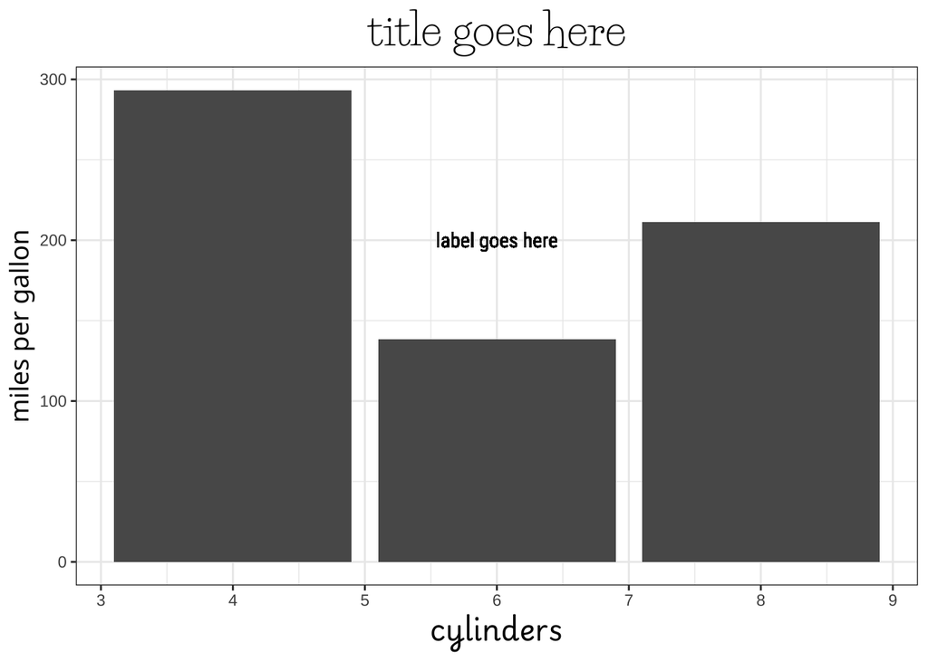

```r
font_add_google("Roboto Condensed","Roboto")
font_add_google("Noto Sans","Noto")
font_add_google("Life Savers","LS")
mtcars |>
  ggplot(aes(x=cyl,y=mpg))+
  geom_col()+
  geom_text(aes(x=6,y=200,label="label goes here"),family="Roboto")+
  labs(title="title goes here",
       x="cylinders",
       y="miles per gallon")+
  theme_bw()+
  theme(plot.title=element_text(family="LS",hjust=.5,size=24),
        axis.title.x=element_text(face="bold",family="playwrite",size=16),
        axis.title.y=element_text(family="Noto",size=14))
```

This Markdown file provides a starting point for font usage in R. Experiment with different families and packages to suit your needs!